# 02- Spatial Analisis Part 1

Geospatial Analysis of the 2023 Earthquakes in Turkey  
**Master Thesis**  
**Master of Data Science**

Gozde Yazganoglu (*gozde.yazganoglu@cunef.edu*)

1. Introduction
2. Importing libraries
3. Point Pattern Analisis

   3.1. Hexbin

   3.2. KDE Kernel Density Estimation

   3.3. Centrography

   3.4. Tendency

   3.5. Randomness and Clustering

   3.6. Alpha shape

   3.7. G-test, F_test
4. Conclusions

## 1.Introduction

Table of content

When assessing building damage level due to an earthquake, using your provided questions, we can frame the inquiries as follows:

1-What does the pattern look like? How do the patterns of damage across buildings manifest? Are there specific parts of the building that are more affected, or is the damage spread evenly?

2-What is the nature of the distribution of points? How is the damage distributed across the affected area? Are there concentrations of buildings with severe damage, or is the damage level scattered unevenly across buildings?

3- Is there any structure in the way locations are arranged over space? That is, are events clustered? or are they dispersed? Do we notice any clusters of buildings with similar damage levels? Is the damage more severe in certain neighborhoods or zones compared to others? Or, on the contrary, is the damage uniformly spread without any discernible pattern?

These questions help in creating a comprehensive assessment of the building damage after an earthquake. They can guide urban planners, architects, and civil engineers in understanding the spatial distribution and causes of damage, thereby aiding in better future urban planning and building design strategies. As well as businesses might be interested to find risks and the factors affecting them.

## 2.Importing Libraries

Back to Table of Contents

We are again need the new geo environment.

```python
#Importing Libraries
import pandas as pd
import matplotlib.pyplot as plt
import geopandas as gpd
import pickle
import numpy as np
import contextily as ctx
import fiona
import seaborn as sns
from pointpats import distance_statistics, QStatistic, random, PointPattern, centrography
from shapely.geometry import Polygon
import libpysal
```

## 3. Point Patern Analisis and Hexibin

Back to Table of Contents

Analyzing Building Behavior in Earthquakes Based on Spatial Patterns and Buildings' response to earthquakes can be interpreted from two primary spatial perspectives.

Firstly, buildings can be seen as static structures within a specific geographical context, meaning their position is predetermined or exogenous. Under this view, a building's location is somewhat secondary compared to the structural or architectural characteristics that determine its resistance to seismic forces. For instance, when evaluating how many buildings in a particular neighborhood survived an earthquake, the neighborhood's geographic location might be constant, and the primary emphasis is on the structural design of the buildings in that area. This approach aligns with how we might assess other spatial entities, such as roads or bridges, within the same earthquake zone.

Secondly, each building's site might be understood as a reflection of the broader, geographically distributed seismic activity. Here, while the impact of earthquakes could be felt anywhere, certain sites are more prone to stronger seismic activities due to underlying geological processes. For example, buildings constructed near fault lines might offer insights into the local seismic behavior, tectonic movements, or even soil liquefaction patterns. Simultaneously, the resilience or damage level of these structures might hint at broader architectural trends and construction standards specific to that region. In this viewpoint, the building's location and its earthquake-related behavior are equally crucial. This dual emphasis will be the cornerstone of our subsequent discussions on the matter.

```python
#reading the data
#
data = gpd.read_file('../data/processed/dataset2.geojson')

data.head()

#alternatively (in case of geojson is killing your kernel)

#data = pd.read_pickle('../data/processed/dataset2.pickle')
```

|  | obj_type | info | damage_gra | locality | population | income | total_sales | second_sales | water_access | elec_cons | ... | fertility | hh_size | longitude | latitude | nearest_water_source_distance | nearest_camping_distance | nearest_earthquake_distance | nearest_fault_distance | elev | geometry |
| --- | --- | --- | --- | --- | --- | --- | --- | --- | --- | --- | --- | --- | --- | --- | --- | --- | --- | --- | --- | --- | --- |
| 0 | 11_RESIDENTIAL_BUILDINGS | 997_NOT_APPLICABLE | 1 | ADIYAMAN | 316140 | 4092 | 40087 | 20574 | 0.98 | 2060 | ... | 2.36 | 4.0 | 38.314252 | 37.768867 | 0.077874 | 0.020232 | 1.121897 | 0.016935 | 660.0 | POLYGON ((38.31461 37.76919, 38.31480 37.76871... |
| 1 | 11_RESIDENTIAL_BUILDINGS | 997_NOT_APPLICABLE | 1 | ADIYAMAN | 316140 | 4092 | 40087 | 20574 | 0.98 | 2060 | ... | 2.36 | 4.0 | 38.313284 | 37.768690 | 0.076904 | 0.019284 | 1.121020 | 0.017440 | 660.0 | POLYGON ((38.31327 37.76841, 38.31297 37.76834... |
| 2 | 12_NON_RESIDENTIAL_BUILDINGS | 1251_INDUSTRIAL_BUILDINGS | 1 | ADIYAMAN | 316140 | 4092 | 40087 | 20574 | 0.98 | 2060 | ... | 2.36 | 4.0 | 38.318013 | 37.768612 | 0.081336 | 0.023588 | 1.125574 | 0.014585 | 660.0 | POLYGON ((38.31832 37.76898, 38.31826 37.76822... |
| 3 | 12_NON_RESIDENTIAL_BUILDINGS | 1251_INDUSTRIAL_BUILDINGS | 1 | ADIYAMAN | 316140 | 4092 | 40087 | 20574 | 0.98 | 2060 | ... | 2.36 | 4.0 | 38.318677 | 37.768575 | 0.081953 | 0.024196 | 1.126222 | 0.014241 | 660.0 | POLYGON ((38.31898 37.76892, 38.31893 37.76819... |
| 4 | 11_RESIDENTIAL_BUILDINGS | 997_NOT_APPLICABLE | 1 | ADIYAMAN | 316140 | 4092 | 40087 | 20574 | 0.98 | 2060 | ... | 2.36 | 4.0 | 38.312542 | 37.768514 | 0.076146 | 0.018542 | 1.120359 | 0.017826 | 660.0 | POLYGON ((38.31286 37.76831, 38.31243 37.76819... |

5 rows × 27 columns

Below plot demonstrates the distribution of the buildings data on affected area. This data includes every single observation. It is expected that since we have 19 different locations, buildings are separated in the area. However, we are able to observe that they tend to distribute in certain places in general.

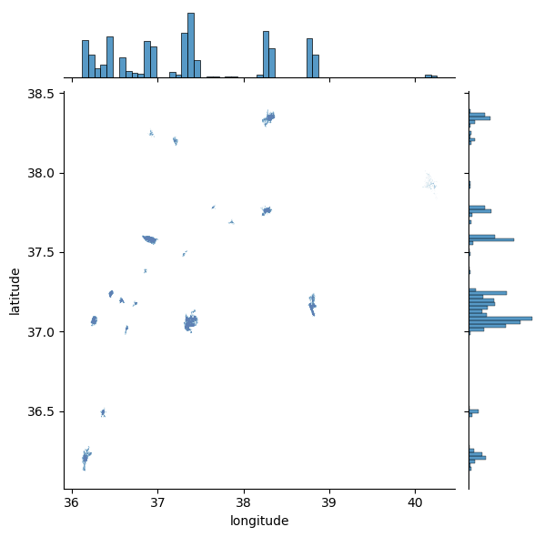

```python
# Generate scatter plot by using longitude and latitude columns
sns.jointplot(x="longitude", y="latitude", data=data, s=0.01);
```

### 3.1. Hexbin :

Our problem is trying to find a density of the spatial distribution. One way to solve this is using hexbin function by python, dividing are a to hexagons. Hexbins are similar to grids and grids are as similar to bar charts where each bar counts things in a particular space. Just like we choose how many bars or categories we want in a bar chart, we decide the number of "buckets" or areas in a grid. This way of counting is quick and can be very detailed. But there's a downside: it can simplify and change how we view things that naturally spread out without clear boundaries.

In our example, in order to demonstrate better grid size is chosen as 150 so that different city centers also can appear on the moap.

Below graph reflect us the density of the all buildings on the map.Our data is not homogenous as builgings are in the city centers.

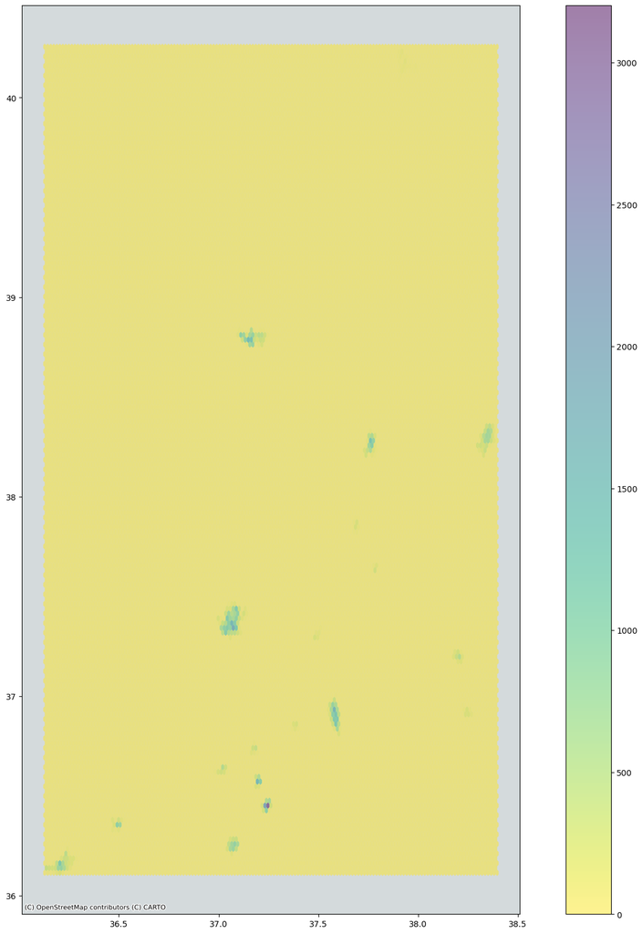

```python
# Set up figure and axis
f, ax = plt.subplots(1, figsize=(20, 20))
# Generate and add hexbin with 150 hexagons in each
# dimension, no borderlines, half transparency,
# and the reverse viridis colormap
hb = ax.hexbin(
    data["latitude"],
    data["longitude"],
    gridsize=150,
    linewidths=0,
    alpha=0.5,
    cmap="viridis_r",
)
# Add basemap
ctx.add_basemap(
    ax, source=ctx.providers.CartoDB.Positron
)
# Add colorbar
plt.colorbar(hb)
```

### 3.2 KDE(Kernel Density Estimation):

Another way to show density is using kernel density histogram. It's like a smooth, even blanket laid over a space. Instead of just counting things in square or hexagon areas, KDE uses special functions, like mini magnets, that pull points towards them. The closer a point is to the magnet, the stronger the pull. All these pulls together make a smooth, continuous surface that shows the likelihood of finding something in any spot. The most popular type of this "magnet" or function is called Gaussian, which pulls points in a bell-curve shape. So, with KDE, we get a smooth map showing where things are likely found.

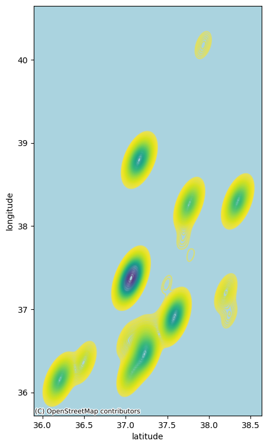

```python
# Set up figure and axis
f, ax = plt.subplots(1, figsize=(12,9))
# Generate and add KDE with a shading of 150 gradients
# coloured contours, 75% of transparency,
# and the reverse viridis colormap
sns.kdeplot(
    x="latitude",
    y="longitude",
    data=data,
    n_levels=100,
    fill = False,
    alpha=0.55,
    cmap="viridis_r",
)
# Add basemap
ctx.add_basemap(
    ax, source=ctx.providers.OpenStreetMap.Mapnik
)
```

Now we can check the where are the damaged buildings and try to locate where they show more density.

First we plot thepoints of the buildings with any level of damage.

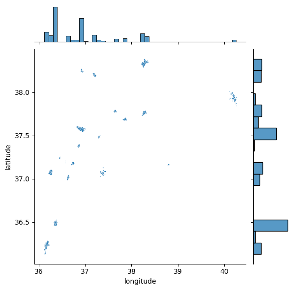

```python
#filtering the buildings which were affected by the earthquake

filtered_data = data[(data['damage_gra'] == 4) | (data['damage_gra'] == 3)| (data['damage_gra'] == 2)]


#Scatter Plot of the buildings which were affected by the earthquake
sns.jointplot(x="longitude", y="latitude", data=filtered_data, s=1);

# Set title
ax.set_title('Damaged and Destroyed buildings')
```

Now we plot hexibins for the filtered data.

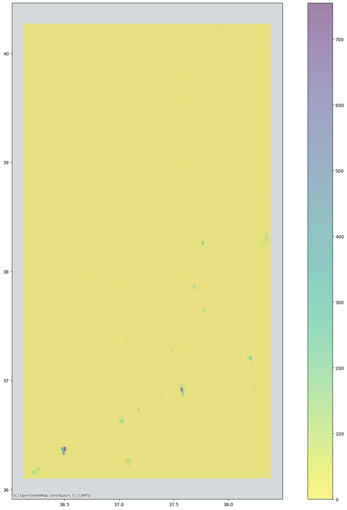

```python
# Set up figure and axis
f, ax = plt.subplots(1, figsize=(20, 20))
# Generate and add hexbin with 150 hexagons in each
# dimension, no borderlines, half transparency,
# and the reverse viridis colormap
hb = ax.hexbin(
    filtered_data["latitude"],
    filtered_data["longitude"],
    gridsize=100,
    linewidths=0,
    alpha=0.5,
    cmap="viridis_r",
)
# Add basemap
ctx.add_basemap(
    ax, source=ctx.providers.CartoDB.Positron
)
# Add colorbar
plt.colorbar(hb)
```

Now we plot KDE for damaged-destroyed points

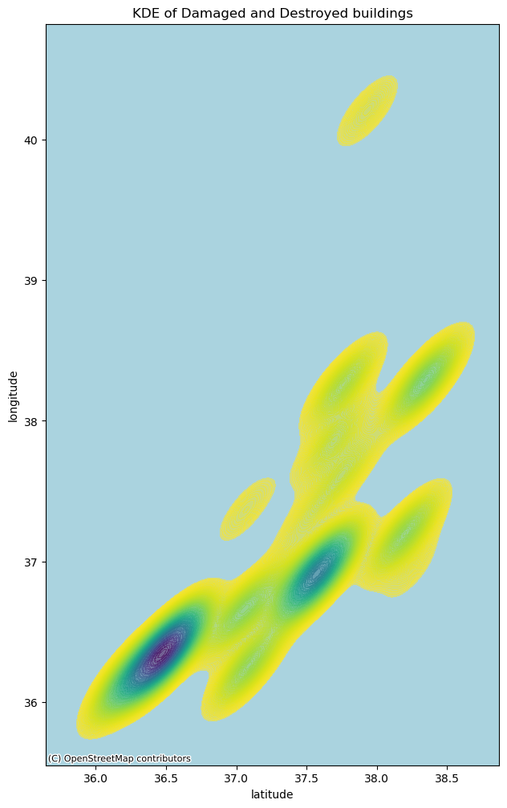

```python
# Set up figure and axis
f, ax = plt.subplots(1, figsize=(9, 12))
# Generate and add KDE with a shading of 50 gradients
# coloured contours, 75% of transparency,
# and the reverse viridis colormap
sns.kdeplot(
    x="latitude",
    y="longitude",
    data=filtered_data,
    n_levels=150,
    shade=True,
    alpha=0.55,
    cmap="viridis_r",
)
# Set title
ax.set_title('KDE of Damaged and Destroyed buildings')


# Add basemap
ctx.add_basemap(
    ax, source=ctx.providers.OpenStreetMap.Mapnik
)
```

Maps have reflected us that although all the buildings are located in other centers, damaged and destroyed buildings are located around different centers. This might be the affect of earthquake or some zones are more more sensitive than others.

## 3.3. Centrography :

Centrography is a study focused on analyzing the centrality of a point pattern. It evaluates the overall location and spread of a pattern, similar to how the mean is used in measures of central tendency. This method helps summarize spatial distributions into more concise information sets, like a single point. Centrography uses various indices to determine the location of a point pattern, its clustering intensity around the center, and the irregularity of its shape.

## 3.4 Tendency:

Tendency is a way to find the middle of point patterns, finding the "heart" of the data. The center of mass is like the average spot of marked data points. If the data points don't have marks, this "heart" or center is just the average location. There's also a "middle" point where half the data is around it, called the median center. We can use centography function of the pointpats library.

Below we are going to examine Centrography and tendency together. We are trying to understand reference to 3 important seismic activity in the disaster day.

```python
#calculating the mean center of the data destroyed and damaged data
mean_center_destroyeddamaged = centrography.mean_center(filtered_data[["latitude", "longitude"]])
med_center_destroyeddamaged = centrography.euclidean_median(filtered_data[["latitude", "longitude"]])
#calculating the mean center of all the data
mean_center_data= centrography.mean_center(data[["latitude", "longitude"]])
med_center_data = centrography.euclidean_median(data[["latitude", "longitude"]])


# Locations of the important earthquakes over magniture 6 on the disaster day.
Pazarcik_point = 37.288, 37.043
Nurdagi_point = 37.304, 36.920
elbistan_point = 38.089, 37.239
```

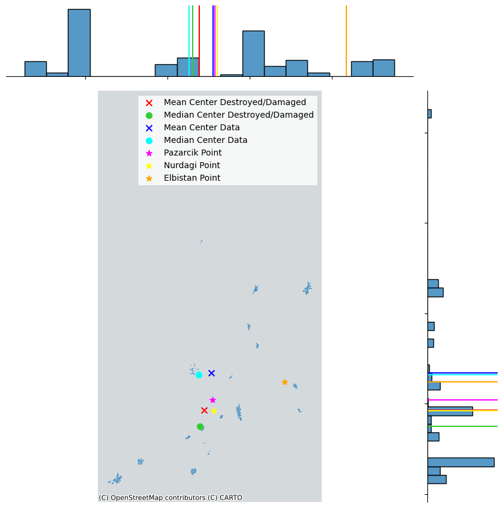

```python
# Generate scatterplot
joint_axes = sns.jointplot(
    x="latitude", y="longitude", data=filtered_data, s=1, height=9
)

# Add points for destroyed and damaged data mean and median centers
for pt, color, marker, label in [
    (mean_center_destroyeddamaged, "red", "x", "Mean Center Destroyed/Damaged"),
    (med_center_destroyeddamaged, "limegreen", "o", "Median Center Destroyed/Damaged"),
    (mean_center_data, "blue", "x", "Mean Center Data"),
    (med_center_data, "cyan", "o", "Median Center Data"),
    (Pazarcik_point, "magenta", "*", "Pazarcik Point"),
    (Nurdagi_point, "yellow", "*", "Nurdagi Point"),
    (elbistan_point, "orange", "*", "Elbistan Point")
]:
    joint_axes.ax_joint.scatter(
        pt[0], pt[1], color=color, marker=marker, s=50, label=label
    )
    joint_axes.ax_marg_x.axvline(pt[0], color=color)
    joint_axes.ax_marg_y.axhline(pt[1], color=color)

# Legend
joint_axes.ax_joint.legend()

# Add basemap
ctx.add_basemap(
    joint_axes.ax_joint, source=ctx.providers.CartoDB.Positron
)

# Clean axes
joint_axes.ax_joint.set_axis_off()

# Display
plt.show()
```

Although the whole data's mean and median are more in the north, we find out that destroyed or damaged buildings are tend to stay aroud the closer points. Meantime the Elbistan earthquake's point is far from the mean and median observations. This area doesn't relatively have many damaged buildings compared to surrounding of other eaarthquakes.

```python
#calculating standard spatial distance for buildings

centrography.std_distance(filtered_data[["latitude", "longitude"]])
```

```
1.0462483908354068
```

The result, 1.0462483908354068, is the computed standard distance value in degrees. To infer from this result:

```
- The value represents the average dispersion of buildings from their mean center in the given dataset. The units are likely the same as those used for the latitude and longitude in degrees.

- A smaller value indicates that buildings are closely packed around their mean center, while a larger value indicates that they are more spread out.
```

```python
major, minor, rotation = centrography.ellipse(filtered_data[["latitude", "longitude"]])

print(major)
print(minor)
print(rotation)
```

```
0.4929304869591131
0.5561041892323519
0.6861460053936527
```

Given the values:

```
major: 0.4929304869591131
minor: 0.5561041892323519
rotation: 0.6861460053936527
```

Here's what you can infer from the data:

```
Major Axis (0.4929304869591131):
```

The length of the major axis of the standard deviational ellipse is approximately 0.493 units. This means that the distribution of your points has its maximum spread along this axis. It's a bit counterintuitive that the "major" axis has a smaller value than the "minor" axis; perhaps there's some mistake or peculiar aspect of the dataset.

```
Minor Axis (0.5561041892323519):
```

The length of the minor axis is approximately 0.556 units. Typically, this would indicate the direction of minimum spread of the dataset, but in this case, the value is larger than the major axis value. This is unusual for a standard deviational ellipse.

```
Rotation (0.6861460053936527):
```

This angle is given in radians (most likely, since it's not close to 90 or 180 which would be expected for degrees in some orientations). The value 0.686 radians is approximately 39.3 degrees when converted. This means that the major axis of your ellipse is rotated approximately 39.3 degrees from the x-axis (or North, in a geographical context).

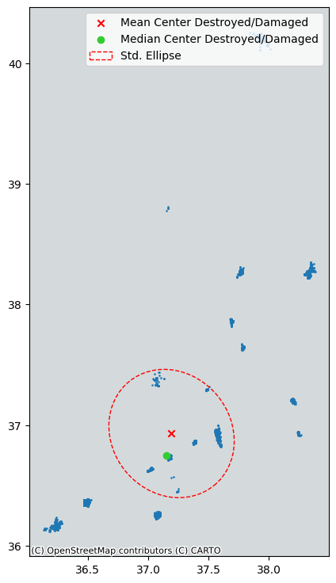

```python
from matplotlib.patches import Ellipse

# Set up figure and axis
f, ax = plt.subplots(1, figsize=(9, 9))
# Plot photograph points
ax.scatter(filtered_data["latitude"], filtered_data["longitude"], s=0.75)
ax.scatter(*mean_center_destroyeddamaged, color="red", marker="x", label="Mean Center Destroyed/Damaged")
ax.scatter(
    *med_center_destroyeddamaged, color="limegreen", marker="o", label="Median Center Destroyed/Damaged"
)

# Construct the standard ellipse using matplotlib
ellipse = Ellipse(
    xy=mean_center_destroyeddamaged,  # center the ellipse on our mean center
    width=major * 2,  # centrography.ellipse only gives half the axis
    height=minor * 2,
    angle=np.rad2deg(
        rotation
    ),  # Angles for this are in degrees, not radians
    facecolor="none",
    edgecolor="red",
    linestyle="--",
    label="Std. Ellipse",
)
ax.add_patch(ellipse)

ax.legend()
# Display
# Add basemap
ctx.add_basemap(
    ax, source=ctx.providers.CartoDB.Positron
)
plt.show()
```

The mean and median centers provide insights into the central tendencies, while the ellipse captures the dispersion.

```
Scatter Points:
```

The blue points represent locations in the filtered_data dataset. They could be various locations of interest, such as incidents or occurrences.

```
Mean Center (Red X):
```

This point represents the average latitude and longitude of destroyed/damaged items. It provides a sense of the "central gravity" of these occurrences.

```
Median Center (Lime-Green O):
```

Unlike the mean, which averages coordinates, the median center represents the middle value of latitudes and longitudes when sorted. It's less sensitive to outliers and provides another perspective on the central location.

```
Standard Deviational Ellipse:
```

This dashed ellipse provides a visual representation of the spatial spread of the data. The orientation (tilt) of the ellipse and its axes lengths indicate the direction and extent of maximum and minimum dispersion of the points.

### 3.5. Randomness and Clustering:

Spatial statistics often look at the evenness of point distributions: whether points group closely together or spread out across an area. This deals with the intensity or spread of the point pattern. The aim is to understand the overall clustering in the pattern, and much work has been done on this topic. Two main methods to study clustering are:

1.Quadrat statistics: This method divides data into small areas called quadrants. These areas are then studied to see how evenly points are distributed across them.

2.Techniques based on Ripley (1988): These focus on measuring the distances between points in a pattern.

```
gstat = 0.0
```

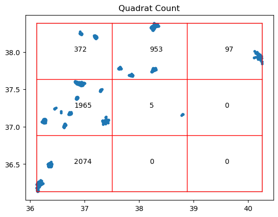

```python
#filtering the data to include only locations
filtered= pd.DataFrame(filtered_data[['longitude', 'latitude']])
#creating pp object to understand point pattern characteristics
pp = PointPattern(filtered.values)

qstat = QStatistic(pp)
print(f'gstat = {qstat.chi2_pvalue}')
QStatistic.
qstat.plot()
```

The QStatistic computes the Q-statistic for a point pattern, which is used to evaluate the randomness of the spatial distribution of points. If the points are randomly distributed, the Q-statistic will be close to 1. If the points tend to be clustered, the Q-statistic will be greater than 1, and if they tend to be uniformly distributed, the Q-statistic will be less than 1.

If the chi2_pvalue is less than 0.05,(in this case) it indicates that the spatial distribution of the points in the filtered dataset is statistically significantly different from a random distribution.

The plot generated by qstat.plot() will provide a visual representation of this distribution, allowing you to determine if the points are more clustered or more evenly spread out than what would be expected under a random distribution.

The actual interpretation depends on the value of chi2_pvalue and the visual characteristics of the plot. For instance, if the p-value is very low and the Q-statistic value is significantly greater than 1, it suggests a clustered pattern.

```python
# Compute bounding box from the data using DataFrame methods
min_x = filtered['longitude'].min()
max_x = filtered['longitude'].max()
min_y = filtered['latitude'].min()
max_y = filtered['latitude'].max()

# Create a Polygon object from the bounding box
bbox_polygon = Polygon([(min_x, min_y), (min_x, max_y), (max_x, max_y), (max_x, min_y)])

# Now generate the Poisson random point pattern using the polygon
random_pattern = random.poisson(bbox_polygon, size=len(filtered))
```

```python
len(random_pattern)
```

```
5466
```

```
chisquare_random = 0.2366073325924277
```

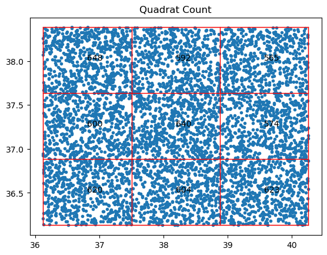

```python
qstat_null = QStatistic(random_pattern)
print(f'chisquare_random = {qstat_null.chi2_pvalue}')
qstat_null.plot()
```

Bounding Box:

The bbox_polygon represents the smallest rectangular area that encompasses all the data points in the filtered dataset. This area provides a boundary within which we can generate or analyze other spatial data.

Random Point Pattern:

The random_pattern is a simulated random distribution of points within the bounding box. By comparing our actual data (filtered) with this random pattern, we can get insights about the spatial nature of our data. For instance, if our actual data appears more clustered or more evenly spread out than the random pattern, it might suggest some underlying spatial process or trend.

In spatial analysis, comparing actual data to random distributions can help in determining whether observed patterns (like clusters or gaps) are meaningful or just due to random chance. This code sets the stage for such an analysis by providing the necessary random pattern for comparison.

As buildings are centered in specific points it is normal to expect buildings will be clustered in these areas. damaged/destroyed buildings are centered in different areas and this is due to the disaster and other variables that affect damage.

### 3.6. Alpha Shape (alpha_shape):

This represents the shape formed by the given set of points, and it can be seen as a flexible "boundary" that encompasses these points. Depending on the context of your data, this might provide insights into regions of interest, clusters, or other spatial phenomena.

```
Alpha Value (alpha):
```

This value gives an indication of the granularity of the computed shape. If you find this value to be small, it means the shape is capturing more detailed features of the point distribution. A larger value would mean a more generalized shape.

```
Circles (circs):
```

These are the circles used in the Delaunay triangulation to compute the alpha shape. Each circle encompasses a subset of the points, and its size is determined by the computed alpha value. These circles can be useful for visualizing how the alpha shape is formed.

```python
# calculating alpha, alpha_shape and circs
alpha_shape, alpha, circs = libpysal.cg.alpha_shape_auto(
    filtered[['longitude', 'latitude']].values, return_circles=True
)
```

Below we visualize the borders of the whole destroyed/damaged data in our data set.

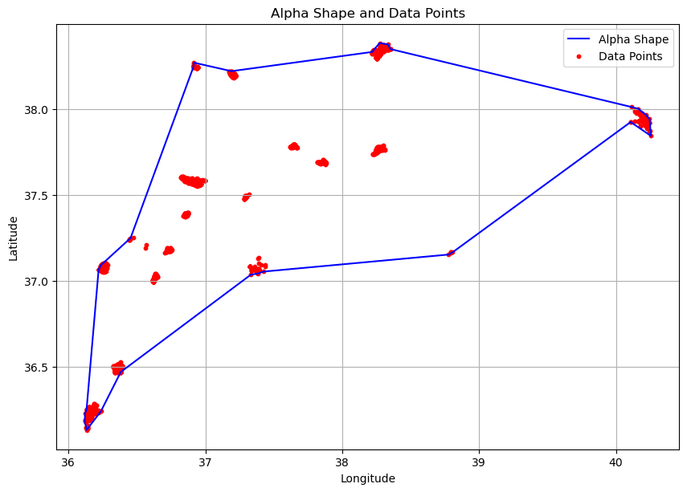

```python
# Convert alpha_shape to a GeoDataFrame
gdf_alpha_shape = gpd.GeoDataFrame(geometry=[alpha_shape], crs="EPSG:4326")

# Create a new plot
fig, ax = plt.subplots(figsize=(10, 10))

# Plot the alpha shape
gdf_alpha_shape.boundary.plot(ax=ax, color='blue', linewidth=1.5, label='Alpha Shape')

# Plot the original data points
ax.scatter(filtered['longitude'], filtered['latitude'], s=10, color='red', label='Data Points')

# If you want to plot the circles as well, you can do it like this:
for circle in circs:
    circle_x, circle_radius = circle
    circle_plot = plt.Circle((circle_x, circle_radius), circle_radius, fill=False, edgecolor='green', linestyle='--')
    ax.add_artist(circle_plot)




ax.legend()
plt.xlabel('Longitude')
plt.ylabel('Latitude')
plt.title('Alpha Shape and Data Points')
plt.grid(True)
plt.show()
```

### 3.7. G_test, F_test:

```
G_test :
```

Observed Distribution: This is derived from our filtered data points. The function calculates a test statistic based on the actual spatial arrangement of these points. It considers how close the points are to each other within a specified distance (support parameter).

Expected Distribution under CSR: This is a theoretical distribution that assumes our data points are distributed randomly in space,with no patterns, clusters, or regularities. The function often simulates numerous random distributions (point patterns) to calculate an expected test statistic under the assumption of CSR.

Comparison: The g_test function will then compare the observed test statistic to the expected one. If there's a significant difference between the two, it indicates that our data points are not randomly distributed.

The results from this test can show:

```
If the points are randomly distributed (no significant difference between observed and expected).
If the points are clustered (closer together than we'd expect by chance).
If the points are dispersed (further apart than we'd expect by chance).
```

The key metric resulting from this comparison is often a p-value. A small p-value (typically less than 0.05) suggests that the observed spatial pattern is statistically significantly different from randomness.

```
F_test:
```

The f_test function, as we've described it within the context of spatial statistics, is another method to analyze the spatial distribution of points. Just like the g_test, the f_test evaluates the spatial pattern of data points compared to a hypothetical random distribution (Complete Spatial Randomness or CSR).

Purpose: The function analyzes the spatial pattern of our points to see if they are randomly distributed in space or if they exhibit clustering or dispersion.

Inputs: The array of points (filtered.values in our case). support: Likely a distance threshold or maximum distance for considering neighboring points. keep_simulations: Indicates that the function will store the results of simulated random patterns for later comparison.

Outputs: Just like with g_test, the outputs would typically include: Observed value of the test statistic based on our data. Expected value under the assumption of CSR. p-value, showing the probability of getting the observed pattern (or more extreme) if the points were truly distributed randomly. Simulated values, if keep_simulations is set to True.

Interpretation: If the observed statistic is notably different from the expected value, then the points aren't randomly distributed. They could be clustered (closer together than we'd expect under randomness) or dispersed (further apart than we'd expect). Examining the simulated values (if kept) will allow us to see how the observed distribution compares visually to random simulations.

While both the g_test and f_test evaluate spatial point patterns, they might calculate different statistics or use different methodologies to compare the observed distribution to that of random patterns. The exact differences would depend on the library or package's specific implementation.

```python
#calculating g_test

g_test = distance_statistics.g_test(
    filtered[['longitude', 'latitude']].values, support=40, keep_simulations=True
)
```

```python
print(g_test)
```

```
GtestResult(support=array([0.        , 0.00083745, 0.00167491, 0.00251236, 0.00334982,
       0.00418727, 0.00502473, 0.00586218, 0.00669964, 0.00753709,
       0.00837455, 0.009212  , 0.01004946, 0.01088691, 0.01172437,
       0.01256182, 0.01339928, 0.01423673, 0.01507419, 0.01591164,
       0.0167491 , 0.01758655, 0.01842401, 0.01926146, 0.02009891,
       0.02093637, 0.02177382, 0.02261128, 0.02344873, 0.02428619,
       0.02512364, 0.0259611 , 0.02679855, 0.02763601, 0.02847346,
       0.02931092, 0.03014837, 0.03098583, 0.03182328, 0.03266074]), statistic=array([0.        , 0.80461032, 0.91035492, 0.95060373, 0.96926454,
       0.9791438 , 0.98335163, 0.98701061, 0.98865715, 0.99195024,
       0.99323088, 0.99506037, 0.99579217, 0.99597512, 0.99615807,
       0.99634102, 0.99670692, 0.99688986, 0.99707281, 0.99725576,
       0.99743871, 0.99743871, 0.99743871, 0.99762166, 0.99798756,
       0.99835346, 0.99853641, 0.99853641, 0.99871936, 0.99890231,
       0.99945115, 0.99945115, 0.99945115, 0.99945115, 0.9996341 ,
       0.9996341 , 0.9996341 , 0.9996341 , 0.99981705, 1.        ]), pvalue=array([0.    , 0.0001, 0.0001, 0.0001, 0.0001, 0.0001, 0.0001, 0.0001,
       0.0001, 0.0001, 0.0001, 0.0001, 0.0001, 0.0001, 0.0001, 0.0001,
       0.0001, 0.0001, 0.0001, 0.0001, 0.0001, 0.0001, 0.0001, 0.0001,
       0.0001, 0.0001, 0.0001, 0.0001, 0.0001, 0.0001, 0.0001, 0.0001,
       0.0001, 0.0001, 0.0001, 0.0001, 0.0001, 0.0001, 0.0001, 0.    ]), simulations=array([[0.00000000e+00, 2.13538330e-03, 8.54153321e-03, ...,
        9.61563101e-01, 9.82916934e-01, 1.00000000e+00],
       [0.00000000e+00, 2.15053763e-03, 3.87096774e-03, ...,
        9.62795699e-01, 9.82150538e-01, 1.00000000e+00],
       [0.00000000e+00, 1.28534704e-03, 5.35561268e-03, ...,
        9.70437018e-01, 9.86503856e-01, 1.00000000e+00],
       ...,
       [0.00000000e+00, 8.58184939e-04, 6.00729457e-03, ...,
        9.67603519e-01, 9.83050847e-01, 1.00000000e+00],
       [0.00000000e+00, 2.56794351e-03, 7.70383052e-03, ...,
        9.65546758e-01, 9.84164348e-01, 1.00000000e+00],
       [0.00000000e+00, 8.60215054e-04, 4.30107527e-03, ...,
        9.60645161e-01, 9.79139785e-01, 1.00000000e+00]]))
```

Low p_values suggest that data points are not randomly distributed in space. They exhibit a spatial pattern that deviates significantly from what would be expected under complete spatial randomness (CSR). The exact nature of this deviation (whether it's clustering or dispersion) would depend on the specific values and trend of the G-test statistic.

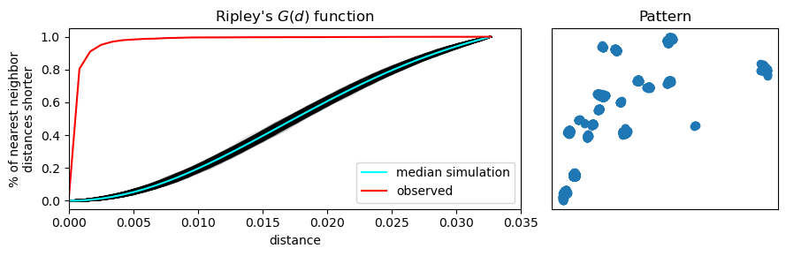

```python
%matplotlib inline
f, ax = plt.subplots(
    1, 2, figsize=(9, 3), gridspec_kw=dict(width_ratios=(6, 3))
)
# plot all the simulations with very fine lines
ax[0].plot(
    g_test.support, g_test.simulations.T, color="k", alpha=0.1
)
# and show the average of simulations
ax[0].plot(
    g_test.support,
    np.median(g_test.simulations, axis=0),
    color="cyan",
    label="median simulation",
)


# and the observed pattern's G function
ax[0].plot(
    g_test.support, g_test.statistic, label="observed", color="red"
)

# clean up labels and axes
ax[0].set_xlabel("distance")
ax[0].set_ylabel("% of nearest neighbor\ndistances shorter")
ax[0].legend()
ax[0].set_xlim(0, 0.035)
ax[0].set_title(r"Ripley's $G(d)$ function")

# plot the pattern itself on the next frame
ax[1].scatter(*filtered.values.T)

# and clean up labels and axes there, too
ax[1].set_xticks([])
ax[1].set_yticks([])
ax[1].set_xticklabels([])
ax[1].set_yticklabels([])
ax[1].set_title("Pattern")
f.tight_layout()
plt.show()
```

On graph we also observe observed values are over medium simulation this also suggest clustering.

```python
#calculating f_test
f_test = distance_statistics.f_test(
    filtered.values, support=40, keep_simulations=True
)
```

```python
print(f_test)
```

```
FtestResult(support=array([0.        , 0.00083745, 0.00167491, 0.00251236, 0.00334982,
       0.00418727, 0.00502473, 0.00586218, 0.00669964, 0.00753709,
       0.00837455, 0.009212  , 0.01004946, 0.01088691, 0.01172437,
       0.01256182, 0.01339928, 0.01423673, 0.01507419, 0.01591164,
       0.0167491 , 0.01758655, 0.01842401, 0.01926146, 0.02009891,
       0.02093637, 0.02177382, 0.02261128, 0.02344873, 0.02428619,
       0.02512364, 0.0259611 , 0.02679855, 0.02763601, 0.02847346,
       0.02931092, 0.03014837, 0.03098583, 0.03182328, 0.03266074]), statistic=array([0.        , 0.        , 0.05555556, 0.05555556, 0.11111111,
       0.11111111, 0.11111111, 0.16666667, 0.16666667, 0.27777778,
       0.33333333, 0.33333333, 0.38888889, 0.44444444, 0.44444444,
       0.44444444, 0.55555556, 0.61111111, 0.61111111, 0.61111111,
       0.61111111, 0.61111111, 0.61111111, 0.61111111, 0.66666667,
       0.66666667, 0.66666667, 0.66666667, 0.66666667, 0.72222222,
       0.77777778, 0.83333333, 0.83333333, 0.94444444, 0.94444444,
       0.94444444, 1.        , 1.        , 1.        , 1.        ]), pvalue=array([0.000e+00, 0.000e+00, 1.000e-04, 1.000e-04, 1.000e-04, 1.000e-04,
       1.000e-04, 1.000e-04, 1.000e-04, 1.000e-04, 1.000e-04, 1.000e-04,
       1.000e-04, 1.000e-04, 1.000e-04, 1.000e-04, 1.000e-04, 1.000e-04,
       1.000e-04, 1.000e-04, 1.000e-04, 1.000e-04, 1.000e-04, 1.770e-02,
       6.000e-04, 8.630e-02, 2.444e-01, 3.400e-03, 0.000e+00, 3.000e-04,
       5.890e-02, 3.118e-01, 5.090e-02, 1.000e-04, 1.000e-04, 9.200e-03,
       1.000e-04, 1.000e-04, 1.000e-04, 0.000e+00]), simulations=array([[0.        , 0.        , 0.0035503 , ..., 0.96568047, 0.98579882,
        1.        ],
       [0.        , 0.002331  , 0.00582751, ..., 0.97435897, 0.98717949,
        1.        ],
       [0.        , 0.00477327, 0.00596659, ..., 0.95346062, 0.9797136 ,
        1.        ],
       ...,
       [0.        , 0.        , 0.00469484, ..., 0.95657277, 0.98474178,
        1.        ],
       [0.        , 0.00116414, 0.00698487, ..., 0.9685681 , 0.98603027,
        1.        ],
       [0.        , 0.00357143, 0.00595238, ..., 0.96666667, 0.98571429,
        1.        ]]))
```

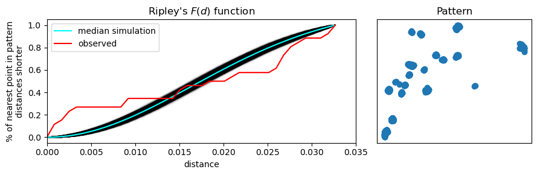

```python
#graphing the Ripley's K function
f, ax = plt.subplots(
    1, 2, figsize=(9, 3), gridspec_kw=dict(width_ratios=(6, 3))
)

# plot all the simulations with very fine lines
ax[0].plot(
    f_test.support, f_test.simulations.T, color="k", alpha=0.01
)
# and show the average of simulations
ax[0].plot(
    f_test.support,
    np.median(f_test.simulations, axis=0),
    color="cyan",
    label="median simulation",
)


# and the observed pattern's F function
ax[0].plot(
    f_test.support, f_test.statistic, label="observed", color="red"
)

# clean up labels and axes
ax[0].set_xlabel("distance")
ax[0].set_ylabel("% of nearest point in pattern\ndistances shorter")
ax[0].legend()
ax[0].set_xlim(0, 0.035)
ax[0].set_title(r"Ripley's $F(d)$ function")

# plot the pattern itself on the next frame
ax[1].scatter(*filtered.values.T)

# and clean up labels and axes there, too
ax[1].set_xticks([])
ax[1].set_yticks([])
ax[1].set_xticklabels([])
ax[1].set_yticklabels([])
ax[1].set_title("Pattern")
f.tight_layout()
plt.show()
```

## 4. Conclusions:

Observations of the damages and destroyed buildings doesn't show a random patern. They are likely to be in clusters.

In the next notebooks we will make a detailed clustering including more variables in unsupervised machine learning models.